# Cyclistic - Bike Share Case Study

Asmita Meshram

27/05/2021

### A Capstone Project for Google Data Analytics Professional Certification

## Business Task:

Understand how casual riders and annual members of Cyclistic - Bike Share use Cyclistic bikes differently and come up with efficient recommendations to convert casual riders into annual members

## Stakeholders

1. Lily Moreno - Director of Marketing
2. Cyclistic marketing analytics team
3. Cyclistic executive team

## Ask Phase of Data Analysis

As it is clear that we want to convert casual members into annual members, we can come up with these SMART questions -

1. How do annual members and casual riders use Cyclistic bikes differently?
2. Why would casual riders buy Cyclistic annual memberships?
3. How can Cyclistic use digital media to influence casual riders to become members?

## Preparing Our Data

The data set we’ll use can be downloaded from [here](https://divvy-tripdata.s3.amazonaws.com/index.html). This dataset is publically available under this [license](https://www.divvybikes.com/data-license-agreement)

##### Installing the required libraries in R

```r
# libraries are already installed using install.packages()
```

```r
library("tidyverse")
library("lubridate")
```

```r
library("ggplot2")
```

```r
getwd()
```

```
## [1] "D:/Main Folder/Google Data Analytics Course/Case Study/Cyclistic_Case_Study"
```

#### Uploading the datasets

```r
data_may20 <- read_csv("DataSet/Clean_ds_null_removed/202005-divvy-tripdata.csv")
data_jun20 <- read_csv("DataSet/Clean_ds_null_removed/202006-divvy-tripdata.csv")
data_jul20 <- read_csv("DataSet/Clean_ds_null_removed/202007-divvy-tripdata.csv")
data_aug20 <- read_csv("DataSet/Clean_ds_null_removed/202008-divvy-tripdata.csv")
data_sep20 <- read_csv("DataSet/Clean_ds_null_removed/202009-divvy-tripdata.csv")
data_oct20 <- read_csv("DataSet/Clean_ds_null_removed/202010-divvy-tripdata.csv")
data_nov20 <- read_csv("DataSet/Clean_ds_null_removed/202011-divvy-tripdata.csv")
data_dec20 <- read_csv("DataSet/Clean_ds_null_removed/202012-divvy-tripdata.csv")
data_jan21 <- read_csv("DataSet/Clean_ds_null_removed/202101-divvy-tripdata.csv")
data_feb21 <- read_csv("DataSet/Clean_ds_null_removed/202102-divvy-tripdata.csv")
data_mar21 <- read_csv("DataSet/Clean_ds_null_removed/202103-divvy-tripdata.csv")
data_apr21 <- read_csv("DataSet/Clean_ds_null_removed/202104-divvy-tripdata.csv")
```

## Processing and Cleaning the datasets

#### Inspecting dataframes

```r
str(data_may20)
```

```
## spec_tbl_df[,15] [199,926 x 15] (S3: spec_tbl_df/tbl_df/tbl/data.frame)
##  $ ride_id           : chr [1:199926] "02668AD35674B983" "7A50CCAF1EDDB28F" "2FFCDFDB91FE9A52" "58991CF1DB75BA84" ...
##  $ rideable_type     : chr [1:199926] "docked_bike" "docked_bike" "docked_bike" "docked_bike" ...
##  $ started_at        : chr [1:199926] "27-05-2020 10:03" "25-05-2020 10:47" "02-05-2020 14:11" "02-05-2020 16:25" ...
##  $ ended_at          : chr [1:199926] "27-05-2020 10:16" "25-05-2020 11:05" "02-05-2020 15:48" "02-05-2020 16:39" ...
##  $ day_of_week       : chr [1:199926] "Wednesday" "Monday" "Saturday" "Saturday" ...
##  $ ride_length       : 'hms' num [1:199926] 00:13:00 00:18:00 01:37:00 00:14:00 ...
##   ..- attr(*, "units")= chr "secs"
##  $ start_station_name: chr [1:199926] "Franklin St & Jackson Blvd" "Clark St & Wrightwood Ave" "Kedzie Ave & Milwaukee Ave" "Clarendon Ave & Leland Ave" ...
##  $ start_station_id  : num [1:199926] 36 340 260 251 261 206 261 180 331 219 ...
##  $ end_station_name  : chr [1:199926] "Wabash Ave & Grand Ave" "Clark St & Leland Ave" "Kedzie Ave & Milwaukee Ave" "Lake Shore Dr & Wellington Ave" ...
##  $ end_station_id    : num [1:199926] 199 326 260 157 206 22 261 180 300 305 ...
##  $ start_lat         : num [1:199926] 41.9 41.9 41.9 42 41.9 ...
##  $ start_lng         : num [1:199926] -87.6 -87.6 -87.7 -87.7 -87.7 ...
##  $ end_lat           : num [1:199926] 41.9 42 41.9 41.9 41.8 ...
##  $ end_lng           : num [1:199926] -87.6 -87.7 -87.7 -87.6 -87.6 ...
##  $ member_casual     : chr [1:199926] "member" "casual" "casual" "casual" ...
##  - attr(*, "spec")=
##   .. cols(
##   ..   ride_id = col_character(),
##   ..   rideable_type = col_character(),
##   ..   started_at = col_character(),
##   ..   ended_at = col_character(),
##   ..   day_of_week = col_character(),
##   ..   ride_length = col_time(format = ""),
##   ..   start_station_name = col_character(),
##   ..   start_station_id = col_double(),
##   ..   end_station_name = col_character(),
##   ..   end_station_id = col_double(),
##   ..   start_lat = col_double(),
##   ..   start_lng = col_double(),
##   ..   end_lat = col_double(),
##   ..   end_lng = col_double(),
##   ..   member_casual = col_character()
##   .. )
```

```r
str(data_jun20)
```

```
## spec_tbl_df[,15] [342,069 x 15] (S3: spec_tbl_df/tbl_df/tbl/data.frame)
##  $ ride_id           : chr [1:342069] "8CD5DE2C2B6C4CFC" "9A191EB2C751D85D" "F37D14B0B5659BCF" "C41237B506E85FA1" ...
##  $ rideable_type     : chr [1:342069] "docked_bike" "docked_bike" "docked_bike" "docked_bike" ...
##  $ started_at        : chr [1:342069] "13-06-2020 23:24" "26-06-2020 07:26" "23-06-2020 17:12" "20-06-2020 01:09" ...
##  $ ended_at          : chr [1:342069] "13-06-2020 23:36" "26-06-2020 07:31" "23-06-2020 17:21" "20-06-2020 01:28" ...
##  $ day_of_week       : chr [1:342069] "Saturday" "Friday" "Tuesday" "Saturday" ...
##  $ ride_length       : 'hms' num [1:342069] 00:12:00 00:05:00 00:08:00 00:18:00 ...
##   ..- attr(*, "units")= chr "secs"
##  $ start_station_name: chr [1:342069] "Wilton Ave & Belmont Ave" "Federal St & Polk St" "Daley Center Plaza" "Broadway & Cornelia Ave" ...
##  $ start_station_id  : num [1:342069] 117 41 81 303 327 327 41 115 338 84 ...
##  $ end_station_name  : chr [1:342069] "Damen Ave & Clybourn Ave" "Daley Center Plaza" "State St & Harrison St" "Broadway & Berwyn Ave" ...
##  $ end_station_id    : num [1:342069] 163 81 5 294 117 117 81 303 164 53 ...
##  $ start_lat         : num [1:342069] 41.9 41.9 41.9 41.9 41.9 ...
##  $ start_lng         : num [1:342069] -87.7 -87.6 -87.6 -87.6 -87.7 ...
##  $ end_lat           : num [1:342069] 41.9 41.9 41.9 42 41.9 ...
##  $ end_lng           : num [1:342069] -87.7 -87.6 -87.6 -87.7 -87.7 ...
##  $ member_casual     : chr [1:342069] "casual" "member" "member" "casual" ...
##  - attr(*, "spec")=
##   .. cols(
##   ..   ride_id = col_character(),
##   ..   rideable_type = col_character(),
##   ..   started_at = col_character(),
##   ..   ended_at = col_character(),
##   ..   day_of_week = col_character(),
##   ..   ride_length = col_time(format = ""),
##   ..   start_station_name = col_character(),
##   ..   start_station_id = col_double(),
##   ..   end_station_name = col_character(),
##   ..   end_station_id = col_double(),
##   ..   start_lat = col_double(),
##   ..   start_lng = col_double(),
##   ..   end_lat = col_double(),
##   ..   end_lng = col_double(),
##   ..   member_casual = col_character()
##   .. )
```

```r
str(data_jul20)
```

```
## spec_tbl_df[,15] [550,044 x 15] (S3: spec_tbl_df/tbl_df/tbl/data.frame)
##  $ ride_id           : chr [1:550044] "762198876D69004D" "BEC9C9FBA0D4CF1B" "D2FD8EA432C77EC1" "54AE594E20B35881" ...
##  $ rideable_type     : chr [1:550044] "docked_bike" "docked_bike" "docked_bike" "docked_bike" ...
##  $ started_at        : chr [1:550044] "09-07-2020 15:22" "24-07-2020 23:56" "08-07-2020 19:49" "17-07-2020 19:06" ...
##  $ ended_at          : chr [1:550044] "09-07-2020 15:25" "25-07-2020 00:20" "08-07-2020 19:56" "17-07-2020 19:27" ...
##  $ day_of_week       : chr [1:550044] "Thursday" "Friday" "Wednesday" "Friday" ...
##  $ ride_length       : 'hms' num [1:550044] 00:03:00 00:24:00 00:07:00 00:21:00 ...
##   ..- attr(*, "units")= chr "secs"
##  $ start_station_name: chr [1:550044] "Ritchie Ct & Banks St" "Halsted St & Roscoe St" "Lake Shore Dr & Diversey Pkwy" "LaSalle St & Illinois St" ...
##  $ start_station_id  : num [1:550044] 180 299 329 181 268 635 113 211 176 31 ...
##  $ end_station_name  : chr [1:550044] "Wells St & Evergreen Ave" "Broadway & Ridge Ave" "Clark St & Wellington Ave" "Clark St & Armitage Ave" ...
##  $ end_station_id    : num [1:550044] 291 461 156 94 301 289 140 31 191 142 ...
##  $ start_lat         : num [1:550044] 41.9 41.9 41.9 41.9 41.9 ...
##  $ start_lng         : num [1:550044] -87.6 -87.6 -87.6 -87.6 -87.6 ...
##  $ end_lat           : num [1:550044] 41.9 42 41.9 41.9 41.9 ...
##  $ end_lng           : num [1:550044] -87.6 -87.7 -87.6 -87.6 -87.6 ...
##  $ member_casual     : chr [1:550044] "member" "member" "casual" "casual" ...
##  - attr(*, "spec")=
##   .. cols(
##   ..   ride_id = col_character(),
##   ..   rideable_type = col_character(),
##   ..   started_at = col_character(),
##   ..   ended_at = col_character(),
##   ..   day_of_week = col_character(),
##   ..   ride_length = col_time(format = ""),
##   ..   start_station_name = col_character(),
##   ..   start_station_id = col_double(),
##   ..   end_station_name = col_character(),
##   ..   end_station_id = col_double(),
##   ..   start_lat = col_double(),
##   ..   start_lng = col_double(),
##   ..   end_lat = col_double(),
##   ..   end_lng = col_double(),
##   ..   member_casual = col_character()
##   .. )
```

```r
str(data_aug20)
```

```
## spec_tbl_df[,15] [605,746 x 15] (S3: spec_tbl_df/tbl_df/tbl/data.frame)
##  $ ride_id           : chr [1:605746] "322BD23D287743ED" "2A3AEF1AB9054D8B" "67DC1D133E8B5816" "C79FBBD412E578A7" ...
##  $ rideable_type     : chr [1:605746] "docked_bike" "electric_bike" "electric_bike" "electric_bike" ...
##  $ started_at        : chr [1:605746] "20-08-2020 18:08" "27-08-2020 18:46" "26-08-2020 19:44" "27-08-2020 12:05" ...
##  $ ended_at          : chr [1:605746] "20-08-2020 18:17" "27-08-2020 19:54" "26-08-2020 21:53" "27-08-2020 12:53" ...
##  $ day_of_week       : chr [1:605746] "Thursday" "Thursday" "Wednesday" "Thursday" ...
##  $ ride_length       : 'hms' num [1:605746] 00:09:00 01:08:00 02:08:00 00:48:00 ...
##   ..- attr(*, "units")= chr "secs"
##  $ start_station_name: chr [1:605746] "Lake Shore Dr & Diversey Pkwy" "Michigan Ave & 14th St" "Columbus Dr & Randolph St" "Daley Center Plaza" ...
##  $ start_station_id  : num [1:605746] 329 168 195 81 658 658 196 67 153 177 ...
##  $ end_station_name  : chr [1:605746] "Clark St & Lincoln Ave" "Michigan Ave & 14th St" "State St & Randolph St" "State St & Kinzie St" ...
##  $ end_station_id    : num [1:605746] 141 168 44 47 658 658 49 229 225 305 ...
##  $ start_lat         : num [1:605746] 41.9 41.9 41.9 41.9 41.9 ...
##  $ start_lng         : num [1:605746] -87.6 -87.6 -87.6 -87.6 -87.7 ...
##  $ end_lat           : num [1:605746] 41.9 41.9 41.9 41.9 41.9 ...
##  $ end_lng           : num [1:605746] -87.6 -87.6 -87.6 -87.6 -87.7 ...
##  $ member_casual     : chr [1:605746] "member" "casual" "casual" "casual" ...
##  - attr(*, "spec")=
##   .. cols(
##   ..   ride_id = col_character(),
##   ..   rideable_type = col_character(),
##   ..   started_at = col_character(),
##   ..   ended_at = col_character(),
##   ..   day_of_week = col_character(),
##   ..   ride_length = col_time(format = ""),
##   ..   start_station_name = col_character(),
##   ..   start_station_id = col_double(),
##   ..   end_station_name = col_character(),
##   ..   end_station_id = col_double(),
##   ..   start_lat = col_double(),
##   ..   start_lng = col_double(),
##   ..   end_lat = col_double(),
##   ..   end_lng = col_double(),
##   ..   member_casual = col_character()
##   .. )
```

```r
str(data_sep20)
```

```
## spec_tbl_df[,15] [498,263 x 15] (S3: spec_tbl_df/tbl_df/tbl/data.frame)
##  $ ride_id           : chr [1:498263] "2B22BD5F95FB2629" "57F6DC9A153DB98C" "B9C4712F78C1AE68" "0CB5E2496B6F1DF8" ...
##  $ rideable_type     : chr [1:498263] "electric_bike" "electric_bike" "electric_bike" "electric_bike" ...
##  $ started_at        : chr [1:498263] "17-09-2020 14:27" "17-09-2020 18:10" "17-09-2020 15:16" "16-09-2020 21:39" ...
##  $ ended_at          : chr [1:498263] "17-09-2020 14:44" "17-09-2020 18:35" "17-09-2020 15:52" "16-09-2020 21:53" ...
##  $ day_of_week       : chr [1:498263] "Thursday" "Thursday" "Thursday" "Wednesday" ...
##  $ ride_length       : 'hms' num [1:498263] 00:17:13 00:25:03 00:36:42 00:13:47 ...
##   ..- attr(*, "units")= chr "secs"
##  $ start_station_name: chr [1:498263] "Michigan Ave & Lake St" "Ashland Ave & Belle Plaine Ave" "Fairbanks Ct & Grand Ave" "Wells St & Evergreen Ave" ...
##  $ start_station_id  : num [1:498263] 52 246 24 291 273 108 511 329 315 138 ...
##  $ end_station_name  : chr [1:498263] "Green St & Randolph St" "Montrose Harbor" "Fairbanks Ct & Grand Ave" "Broadway & Sheridan Rd" ...
##  $ end_station_id    : num [1:498263] 112 249 24 256 273 339 511 268 464 504 ...
##  $ start_lat         : num [1:498263] 41.9 42 41.9 41.9 41.9 ...
##  $ start_lng         : num [1:498263] -87.6 -87.7 -87.6 -87.6 -87.6 ...
##  $ end_lat           : num [1:498263] 41.9 42 41.9 42 41.9 ...
##  $ end_lng           : num [1:498263] -87.6 -87.6 -87.6 -87.7 -87.6 ...
##  $ member_casual     : chr [1:498263] "casual" "casual" "casual" "casual" ...
##  - attr(*, "spec")=
##   .. cols(
##   ..   ride_id = col_character(),
##   ..   rideable_type = col_character(),
##   ..   started_at = col_character(),
##   ..   ended_at = col_character(),
##   ..   day_of_week = col_character(),
##   ..   ride_length = col_time(format = ""),
##   ..   start_station_name = col_character(),
##   ..   start_station_id = col_double(),
##   ..   end_station_name = col_character(),
##   ..   end_station_id = col_double(),
##   ..   start_lat = col_double(),
##   ..   start_lng = col_double(),
##   ..   end_lat = col_double(),
##   ..   end_lng = col_double(),
##   ..   member_casual = col_character()
##   .. )
```

```r
str(data_oct20)
```

```
## spec_tbl_df[,15] [338,298 x 15] (S3: spec_tbl_df/tbl_df/tbl/data.frame)
##  $ ride_id           : chr [1:338298] "ACB6B40CF5B9044C" "DF450C72FD109C01" "B6396B54A15AC0DF" "44A4AEE261B9E854" ...
##  $ rideable_type     : chr [1:338298] "electric_bike" "electric_bike" "electric_bike" "electric_bike" ...
##  $ started_at        : chr [1:338298] "31-10-2020 19:39" "31-10-2020 23:50" "31-10-2020 23:00" "31-10-2020 22:16" ...
##  $ ended_at          : chr [1:338298] "31-10-2020 19:57" "01-11-2020 00:04" "31-10-2020 23:08" "31-10-2020 22:19" ...
##  $ day_of_week       : chr [1:338298] "Saturday" "Saturday" "Saturday" "Saturday" ...
##  $ ride_length       : 'hms' num [1:338298] 00:18:00 00:14:00 00:08:00 00:03:00 ...
##   ..- attr(*, "units")= chr "secs"
##  $ start_station_name: chr [1:338298] "Lakeview Ave & Fullerton Pkwy" "Southport Ave & Waveland Ave" "Stony Island Ave & 67th St" "Clark St & Grace St" ...
##  $ start_station_id  : num [1:338298] 313 227 102 165 190 359 313 125 174 114 ...
##  $ end_station_name  : chr [1:338298] "Rush St & Hubbard St" "Kedzie Ave & Milwaukee Ave" "University Ave & 57th St" "Broadway & Sheridan Rd" ...
##  $ end_station_id    : num [1:338298] 125 260 423 256 185 53 125 313 635 303 ...
##  $ start_lat         : num [1:338298] 41.9 41.9 41.8 42 41.9 ...
##  $ start_lng         : num [1:338298] -87.6 -87.7 -87.6 -87.7 -87.7 ...
##  $ end_lat           : num [1:338298] 41.9 41.9 41.8 42 41.9 ...
##  $ end_lng           : num [1:338298] -87.6 -87.7 -87.6 -87.7 -87.7 ...
##  $ member_casual     : chr [1:338298] "casual" "casual" "casual" "casual" ...
##  - attr(*, "spec")=
##   .. cols(
##   ..   ride_id = col_character(),
##   ..   rideable_type = col_character(),
##   ..   started_at = col_character(),
##   ..   ended_at = col_character(),
##   ..   day_of_week = col_character(),
##   ..   ride_length = col_time(format = ""),
##   ..   start_station_name = col_character(),
##   ..   start_station_id = col_double(),
##   ..   end_station_name = col_character(),
##   ..   end_station_id = col_double(),
##   ..   start_lat = col_double(),
##   ..   start_lng = col_double(),
##   ..   end_lat = col_double(),
##   ..   end_lng = col_double(),
##   ..   member_casual = col_character()
##   .. )
```

```r
str(data_nov20)
```

```
## spec_tbl_df[,15] [221,935 x 15] (S3: spec_tbl_df/tbl_df/tbl/data.frame)
##  $ ride_id           : chr [1:221935] "BD0A6FF6FFF9B921" "96A7A7A4BDE4F82D" "C61526D06582BDC5" "E533E89C32080B9E" ...
##  $ rideable_type     : chr [1:221935] "electric_bike" "electric_bike" "electric_bike" "electric_bike" ...
##  $ started_at        : chr [1:221935] "01-11-2020 13:36" "01-11-2020 10:03" "01-11-2020 00:34" "01-11-2020 00:45" ...
##  $ ended_at          : chr [1:221935] "01-11-2020 13:45" "01-11-2020 10:14" "01-11-2020 01:03" "01-11-2020 00:54" ...
##  $ day_of_week       : chr [1:221935] "Sunday" "Sunday" "Sunday" "Sunday" ...
##  $ ride_length       : 'hms' num [1:221935] 00:09:40 00:11:19 00:29:01 00:09:15 ...
##   ..- attr(*, "units")= chr "secs"
##  $ start_station_name: chr [1:221935] "Dearborn St & Erie St" "Franklin St & Illinois St" "Lake Shore Dr & Monroe St" "Leavitt St & Chicago Ave" ...
##  $ start_station_id  : num [1:221935] 110 672 76 659 2 72 76 58 394 623 ...
##  $ end_station_name  : chr [1:221935] "St. Clair St & Erie St" "Noble St & Milwaukee Ave" "Federal St & Polk St" "Stave St & Armitage Ave" ...
##  $ end_station_id    : num [1:221935] 211 29 41 185 2 76 72 288 273 2 ...
##  $ start_lat         : num [1:221935] 41.9 41.9 41.9 41.9 41.9 ...
##  $ start_lng         : num [1:221935] -87.6 -87.6 -87.6 -87.7 -87.6 ...
##  $ end_lat           : num [1:221935] 41.9 41.9 41.9 41.9 41.9 ...
##  $ end_lng           : num [1:221935] -87.6 -87.7 -87.6 -87.7 -87.6 ...
##  $ member_casual     : chr [1:221935] "casual" "casual" "casual" "casual" ...
##  - attr(*, "spec")=
##   .. cols(
##   ..   ride_id = col_character(),
##   ..   rideable_type = col_character(),
##   ..   started_at = col_character(),
##   ..   ended_at = col_character(),
##   ..   day_of_week = col_character(),
##   ..   ride_length = col_time(format = ""),
##   ..   start_station_name = col_character(),
##   ..   start_station_id = col_double(),
##   ..   end_station_name = col_character(),
##   ..   end_station_id = col_double(),
##   ..   start_lat = col_double(),
##   ..   start_lng = col_double(),
##   ..   end_lat = col_double(),
##   ..   end_lng = col_double(),
##   ..   member_casual = col_character()
##   .. )
```

```r
str(data_dec20)
```

```
## spec_tbl_df[,15] [113,541 x 15] (S3: spec_tbl_df/tbl_df/tbl/data.frame)
##  $ ride_id           : chr [1:113541] "70B6A9A437D4C30D" "15F369FDAED4E8E3" "0CFD61DFE00E6043" "244CB936487039B7" ...
##  $ rideable_type     : chr [1:113541] "classic_bike" "electric_bike" "electric_bike" "docked_bike" ...
##  $ started_at        : chr [1:113541] "27-12-2020 12:44" "18-12-2020 13:53" "28-12-2020 17:10" "10-12-2020 13:36" ...
##  $ ended_at          : chr [1:113541] "27-12-2020 12:55" "18-12-2020 14:01" "28-12-2020 17:12" "10-12-2020 14:37" ...
##  $ day_of_week       : chr [1:113541] "Sunday" "Friday" "Monday" "Thursday" ...
##  $ ride_length       : 'hms' num [1:113541] 00:10:37 00:07:50 00:01:48 01:00:47 ...
##   ..- attr(*, "units")= chr "secs"
##  $ start_station_name: chr [1:113541] "Aberdeen St & Jackson Blvd" "Larrabee St & Armitage Ave" "Kingsbury St & Kinzie St" "Clark St & Leland Ave" ...
##  $ start_station_id  : chr [1:113541] "13157" "TA1309000006" "KA1503000043" "TA1309000014" ...
##  $ end_station_name  : chr [1:113541] "Desplaines St & Kinzie St" "Wells St & Walton St" "Desplaines St & Kinzie St" "Clark St & Leland Ave" ...
##  $ end_station_id    : chr [1:113541] "TA1306000003" "TA1306000011" "TA1306000003" "TA1309000014" ...
##  $ start_lat         : num [1:113541] 41.9 41.9 41.9 42 41.9 ...
##  $ start_lng         : num [1:113541] -87.7 -87.6 -87.6 -87.7 -87.6 ...
##  $ end_lat           : num [1:113541] 41.9 41.9 41.9 42 41.9 ...
##  $ end_lng           : num [1:113541] -87.6 -87.6 -87.6 -87.7 -87.6 ...
##  $ member_casual     : chr [1:113541] "member" "member" "member" "casual" ...
##  - attr(*, "spec")=
##   .. cols(
##   ..   ride_id = col_character(),
##   ..   rideable_type = col_character(),
##   ..   started_at = col_character(),
##   ..   ended_at = col_character(),
##   ..   day_of_week = col_character(),
##   ..   ride_length = col_time(format = ""),
##   ..   start_station_name = col_character(),
##   ..   start_station_id = col_character(),
##   ..   end_station_name = col_character(),
##   ..   end_station_id = col_character(),
##   ..   start_lat = col_double(),
##   ..   start_lng = col_double(),
##   ..   end_lat = col_double(),
##   ..   end_lng = col_double(),
##   ..   member_casual = col_character()
##   .. )
```

```r
str(data_jan21)
```

```
## spec_tbl_df[,15] [83,509 x 15] (S3: spec_tbl_df/tbl_df/tbl/data.frame)
##  $ ride_id           : chr [1:83509] "B9F73448DFBE0D45" "457C7F4B5D3DA135" "57C750326F9FDABE" "4D518C65E338D070" ...
##  $ rideable_type     : chr [1:83509] "classic_bike" "electric_bike" "electric_bike" "electric_bike" ...
##  $ started_at        : chr [1:83509] "24-01-2021 19:15" "23-01-2021 12:57" "09-01-2021 15:28" "09-01-2021 15:28" ...
##  $ ended_at          : chr [1:83509] "24-01-2021 19:22" "23-01-2021 13:02" "09-01-2021 15:37" "09-01-2021 15:37" ...
##  $ day_of_week       : chr [1:83509] "Sunday" "Saturday" "Saturday" "Saturday" ...
##  $ ride_length       : 'hms' num [1:83509] 00:07:13 00:04:32 00:09:47 00:08:57 ...
##   ..- attr(*, "units")= chr "secs"
##  $ start_station_name: chr [1:83509] "California Ave & Cortez St" "California Ave & Cortez St" "California Ave & Cortez St" "California Ave & Cortez St" ...
##  $ start_station_id  : chr [1:83509] "17660" "17660" "17660" "17660" ...
##  $ end_station_name  : chr [1:83509] "Wood St & Augusta Blvd" "California Ave & North Ave" "Wood St & Augusta Blvd" "Wood St & Augusta Blvd" ...
##  $ end_station_id    : chr [1:83509] "657" "13258" "657" "657" ...
##  $ start_lat         : num [1:83509] 41.9 41.9 41.9 41.9 41.9 ...
##  $ start_lng         : num [1:83509] -87.7 -87.7 -87.7 -87.7 -87.7 ...
##  $ end_lat           : num [1:83509] 41.9 41.9 41.9 41.9 41.9 ...
##  $ end_lng           : num [1:83509] -87.7 -87.7 -87.7 -87.7 -87.7 ...
##  $ member_casual     : chr [1:83509] "member" "member" "casual" "casual" ...
##  - attr(*, "spec")=
##   .. cols(
##   ..   ride_id = col_character(),
##   ..   rideable_type = col_character(),
##   ..   started_at = col_character(),
##   ..   ended_at = col_character(),
##   ..   day_of_week = col_character(),
##   ..   ride_length = col_time(format = ""),
##   ..   start_station_name = col_character(),
##   ..   start_station_id = col_character(),
##   ..   end_station_name = col_character(),
##   ..   end_station_id = col_character(),
##   ..   start_lat = col_double(),
##   ..   start_lng = col_double(),
##   ..   end_lat = col_double(),
##   ..   end_lng = col_double(),
##   ..   member_casual = col_character()
##   .. )
```

```r
str(data_feb21)
```

```
## spec_tbl_df[,15] [42,996 x 15] (S3: spec_tbl_df/tbl_df/tbl/data.frame)
##  $ ride_id           : chr [1:42996] "89E7AA6C29227EFF" "0FEFDE2603568365" "E6159D746B2DBB91" "B32D3199F1C2E75B" ...
##  $ rideable_type     : chr [1:42996] "classic_bike" "classic_bike" "electric_bike" "classic_bike" ...
##  $ started_at        : chr [1:42996] "12-02-2021 16:14" "14-02-2021 17:52" "09-02-2021 19:10" "02-02-2021 17:49" ...
##  $ ended_at          : chr [1:42996] "12-02-2021 16:21" "14-02-2021 18:12" "09-02-2021 19:19" "02-02-2021 17:54" ...
##  $ day_of_week       : chr [1:42996] "Friday" "Sunday" "Tuesday" "Tuesday" ...
##  $ ride_length       : 'hms' num [1:42996] 00:06:47 00:19:31 00:08:52 00:04:25 ...
##   ..- attr(*, "units")= chr "secs"
##  $ start_station_name: chr [1:42996] "Glenwood Ave & Touhy Ave" "Glenwood Ave & Touhy Ave" "Clark St & Lake St" "Wood St & Chicago Ave" ...
##  $ start_station_id  : chr [1:42996] "525" "525" "KA1503000012" "637" ...
##  $ end_station_name  : chr [1:42996] "Sheridan Rd & Columbia Ave" "Bosworth Ave & Howard St" "State St & Randolph St" "Honore St & Division St" ...
##  $ end_station_id    : chr [1:42996] "660" "16806" "TA1305000029" "TA1305000034" ...
##  $ start_lat         : num [1:42996] 42 42 41.9 41.9 41.8 ...
##  $ start_lng         : num [1:42996] -87.7 -87.7 -87.6 -87.7 -87.6 ...
##  $ end_lat           : num [1:42996] 42 42 41.9 41.9 41.8 ...
##  $ end_lng           : num [1:42996] -87.7 -87.7 -87.6 -87.7 -87.6 ...
##  $ member_casual     : chr [1:42996] "member" "casual" "member" "member" ...
##  - attr(*, "spec")=
##   .. cols(
##   ..   ride_id = col_character(),
##   ..   rideable_type = col_character(),
##   ..   started_at = col_character(),
##   ..   ended_at = col_character(),
##   ..   day_of_week = col_character(),
##   ..   ride_length = col_time(format = ""),
##   ..   start_station_name = col_character(),
##   ..   start_station_id = col_character(),
##   ..   end_station_name = col_character(),
##   ..   end_station_id = col_character(),
##   ..   start_lat = col_double(),
##   ..   start_lng = col_double(),
##   ..   end_lat = col_double(),
##   ..   end_lng = col_double(),
##   ..   member_casual = col_character()
##   .. )
```

```r
str(data_mar21)
```

```
## spec_tbl_df[,15] [205,689 x 15] (S3: spec_tbl_df/tbl_df/tbl/data.frame)
##  $ ride_id           : chr [1:205689] "CFA86D4455AA1030" "30D9DC61227D1AF3" "846D87A15682A284" "994D05AA75A168F2" ...
##  $ rideable_type     : chr [1:205689] "classic_bike" "classic_bike" "classic_bike" "classic_bike" ...
##  $ started_at        : chr [1:205689] "16-03-2021 08:32" "28-03-2021 01:26" "11-03-2021 21:17" "11-03-2021 13:26" ...
##  $ ended_at          : chr [1:205689] "16-03-2021 08:36" "28-03-2021 01:36" "11-03-2021 21:33" "11-03-2021 13:55" ...
##  $ day_of_week       : chr [1:205689] "Tuesday" "Sunday" "Thursday" "Thursday" ...
##  $ ride_length       : 'hms' num [1:205689] 00:04:04 00:10:27 00:16:24 00:28:59 ...
##   ..- attr(*, "units")= chr "secs"
##  $ start_station_name: chr [1:205689] "Humboldt Blvd & Armitage Ave" "Humboldt Blvd & Armitage Ave" "Shields Ave & 28th Pl" "Winthrop Ave & Lawrence Ave" ...
##  $ start_station_id  : chr [1:205689] "15651" "15651" "15443" "TA1308000021" ...
##  $ end_station_name  : chr [1:205689] "Stave St & Armitage Ave" "Central Park Ave & Bloomingdale Ave" "Halsted St & 35th St" "Broadway & Sheridan Rd" ...
##  $ end_station_id    : chr [1:205689] "13266" "18017" "TA1308000043" "13323" ...
##  $ start_lat         : num [1:205689] 41.9 41.9 41.8 42 42 ...
##  $ start_lng         : num [1:205689] -87.7 -87.7 -87.6 -87.7 -87.7 ...
##  $ end_lat           : num [1:205689] 41.9 41.9 41.8 42 42.1 ...
##  $ end_lng           : num [1:205689] -87.7 -87.7 -87.6 -87.6 -87.7 ...
##  $ member_casual     : chr [1:205689] "casual" "casual" "casual" "casual" ...
##  - attr(*, "spec")=
##   .. cols(
##   ..   ride_id = col_character(),
##   ..   rideable_type = col_character(),
##   ..   started_at = col_character(),
##   ..   ended_at = col_character(),
##   ..   day_of_week = col_character(),
##   ..   ride_length = col_time(format = ""),
##   ..   start_station_name = col_character(),
##   ..   start_station_id = col_character(),
##   ..   end_station_name = col_character(),
##   ..   end_station_id = col_character(),
##   ..   start_lat = col_double(),
##   ..   start_lng = col_double(),
##   ..   end_lat = col_double(),
##   ..   end_lng = col_double(),
##   ..   member_casual = col_character()
##   .. )
```

```r
str(data_apr21)
```

```
## spec_tbl_df[,15] [298,203 x 15] (S3: spec_tbl_df/tbl_df/tbl/data.frame)
##  $ ride_id           : chr [1:298203] "6C992BD37A98A63F" "1E0145613A209000" "E498E15508A80BAD" "1887262AD101C604" ...
##  $ rideable_type     : chr [1:298203] "classic_bike" "docked_bike" "docked_bike" "classic_bike" ...
##  $ started_at        : chr [1:298203] "12-04-2021 18:25" "27-04-2021 17:27" "03-04-2021 12:42" "17-04-2021 09:17" ...
##  $ ended_at          : chr [1:298203] "12-04-2021 18:56" "27-04-2021 18:31" "07-04-2021 11:40" "17-04-2021 09:42" ...
##  $ day_of_week       : chr [1:298203] "Monday" "Tuesday" "Saturday" "Saturday" ...
##  $ ride_length       : 'hms' num [1:298203] 00:31:19 01:04:18 22:57:39 00:25:06 ...
##   ..- attr(*, "units")= chr "secs"
##  $ start_station_name: chr [1:298203] "State St & Pearson St" "Dorchester Ave & 49th St" "Loomis Blvd & 84th St" "Honore St & Division St" ...
##  $ start_station_id  : chr [1:298203] "TA1307000061" "KA1503000069" "20121" "TA1305000034" ...
##  $ end_station_name  : chr [1:298203] "Southport Ave & Waveland Ave" "Dorchester Ave & 49th St" "Loomis Blvd & 84th St" "Southport Ave & Waveland Ave" ...
##  $ end_station_id    : chr [1:298203] "13235" "KA1503000069" "20121" "13235" ...
##  $ start_lat         : num [1:298203] 41.9 41.8 41.7 41.9 41.7 ...
##  $ start_lng         : num [1:298203] -87.6 -87.6 -87.7 -87.7 -87.7 ...
##  $ end_lat           : num [1:298203] 41.9 41.8 41.7 41.9 41.7 ...
##  $ end_lng           : num [1:298203] -87.7 -87.6 -87.7 -87.7 -87.7 ...
##  $ member_casual     : chr [1:298203] "member" "casual" "casual" "member" ...
##  - attr(*, "spec")=
##   .. cols(
##   ..   ride_id = col_character(),
##   ..   rideable_type = col_character(),
##   ..   started_at = col_character(),
##   ..   ended_at = col_character(),
##   ..   day_of_week = col_character(),
##   ..   ride_length = col_time(format = ""),
##   ..   start_station_name = col_character(),
##   ..   start_station_id = col_character(),
##   ..   end_station_name = col_character(),
##   ..   end_station_id = col_character(),
##   ..   start_lat = col_double(),
##   ..   start_lng = col_double(),
##   ..   end_lat = col_double(),
##   ..   end_lng = col_double(),
##   ..   member_casual = col_character()
##   .. )
```

We can see in column specifications that start_station_id and end_station_id does not have consistent datatype. So we will change it to character datatype

```r
data_may20 <-  mutate(data_may20, start_station_id = as.character(start_station_id)
                      ,end_station_id = as.character(end_station_id))
data_jun20 <-  mutate(data_jun20, start_station_id = as.character(start_station_id)
                      ,end_station_id = as.character(end_station_id))
data_jul20 <-  mutate(data_jul20, start_station_id = as.character(start_station_id)
                      ,end_station_id = as.character(end_station_id))
data_aug20 <-  mutate(data_aug20, start_station_id = as.character(start_station_id)
                      ,end_station_id = as.character(end_station_id))
data_sep20 <-  mutate(data_sep20, start_station_id = as.character(start_station_id)
                      ,end_station_id = as.character(end_station_id))
data_oct20 <-  mutate(data_oct20, start_station_id = as.character(start_station_id)
                      ,end_station_id = as.character(end_station_id))
data_nov20 <-  mutate(data_nov20, start_station_id = as.character(start_station_id)
                      ,end_station_id = as.character(end_station_id))
data_dec20 <-  mutate(data_dec20, start_station_id = as.character(start_station_id)
                      ,end_station_id = as.character(end_station_id))
data_jan21 <-  mutate(data_jan21, start_station_id = as.character(start_station_id)
                      ,end_station_id = as.character(end_station_id))
data_feb21 <-  mutate(data_feb21, start_station_id = as.character(start_station_id)
                      ,end_station_id = as.character(end_station_id))
data_mar21 <-  mutate(data_mar21, start_station_id = as.character(start_station_id)
                      ,end_station_id = as.character(end_station_id))
data_apr21 <-  mutate(data_apr21, start_station_id = as.character(start_station_id)
                      ,end_station_id = as.character(end_station_id))
```

#### Combining all datasets into a single dataset

```r
trips <- bind_rows(data_may20,data_jun20,data_jul20,data_aug20,data_sep20,data_oct20,data_nov20,data_dec20,data_jan21,data_feb21,data_mar21,data_apr21)
```

Longitude and latitude columns can be dropped as there is no need of them

```r
trips <- trips %>%
  select(-c(start_lat,start_lng,end_lat,end_lng))
```

### Formatting data for our convenience

```r
trips$date <- as.Date(trips$started_at, "%d-%m-%Y")

trips$month <- format(as.Date(trips$date),"%m")

trips$day <- format(as.Date(trips$date),"%d")

trips$year <- format(as.Date(trips$date), "%Y")

trips$month_group <- format(as.Date(trips$date), "%Y-%m")
```

#### Summarizing data for analysis

```r
colnames(trips)
```

```
##  [1] "ride_id"            "rideable_type"      "started_at"
##  [4] "ended_at"           "day_of_week"        "ride_length"
##  [7] "start_station_name" "start_station_id"   "end_station_name"
## [10] "end_station_id"     "member_casual"      "date"
## [13] "month"              "day"                "year"
## [16] "month_group"
```

```r
nrow(trips)
```

```
## [1] 3500219
```

```r
dim(trips)
```

```
## [1] 3500219      16
```

```r
head(trips)
```

```
## # A tibble: 6 x 16
##   ride_id       rideable_type started_at    ended_at     day_of_week ride_length
##   <chr>         <chr>         <chr>         <chr>        <chr>       <time>
## 1 02668AD35674~ docked_bike   27-05-2020 1~ 27-05-2020 ~ Wednesday   00:13
## 2 7A50CCAF1EDD~ docked_bike   25-05-2020 1~ 25-05-2020 ~ Monday      00:18
## 3 2FFCDFDB91FE~ docked_bike   02-05-2020 1~ 02-05-2020 ~ Saturday    01:37
## 4 58991CF1DB75~ docked_bike   02-05-2020 1~ 02-05-2020 ~ Saturday    00:14
## 5 A79651EFECC2~ docked_bike   29-05-2020 1~ 29-05-2020 ~ Friday      00:38
## 6 1466C5B39F68~ docked_bike   29-05-2020 1~ 29-05-2020 ~ Friday      00:47
## # ... with 10 more variables: start_station_name <chr>, start_station_id <chr>,
## #   end_station_name <chr>, end_station_id <chr>, member_casual <chr>,
## #   date <date>, month <chr>, day <chr>, year <chr>, month_group <chr>
```

```r
str(trips)
```

```
## tibble[,16] [3,500,219 x 16] (S3: tbl_df/tbl/data.frame)
##  $ ride_id           : chr [1:3500219] "02668AD35674B983" "7A50CCAF1EDDB28F" "2FFCDFDB91FE9A52" "58991CF1DB75BA84" ...
##  $ rideable_type     : chr [1:3500219] "docked_bike" "docked_bike" "docked_bike" "docked_bike" ...
##  $ started_at        : chr [1:3500219] "27-05-2020 10:03" "25-05-2020 10:47" "02-05-2020 14:11" "02-05-2020 16:25" ...
##  $ ended_at          : chr [1:3500219] "27-05-2020 10:16" "25-05-2020 11:05" "02-05-2020 15:48" "02-05-2020 16:39" ...
##  $ day_of_week       : chr [1:3500219] "Wednesday" "Monday" "Saturday" "Saturday" ...
##  $ ride_length       : 'hms' num [1:3500219] 00:13:00 00:18:00 01:37:00 00:14:00 ...
##   ..- attr(*, "units")= chr "secs"
##  $ start_station_name: chr [1:3500219] "Franklin St & Jackson Blvd" "Clark St & Wrightwood Ave" "Kedzie Ave & Milwaukee Ave" "Clarendon Ave & Leland Ave" ...
##  $ start_station_id  : chr [1:3500219] "36" "340" "260" "251" ...
##  $ end_station_name  : chr [1:3500219] "Wabash Ave & Grand Ave" "Clark St & Leland Ave" "Kedzie Ave & Milwaukee Ave" "Lake Shore Dr & Wellington Ave" ...
##  $ end_station_id    : chr [1:3500219] "199" "326" "260" "157" ...
##  $ member_casual     : chr [1:3500219] "member" "casual" "casual" "casual" ...
##  $ date              : Date[1:3500219], format: "2020-05-27" "2020-05-25" ...
##  $ month             : chr [1:3500219] "05" "05" "05" "05" ...
##  $ day               : chr [1:3500219] "27" "25" "02" "02" ...
##  $ year              : chr [1:3500219] "2020" "2020" "2020" "2020" ...
##  $ month_group       : chr [1:3500219] "2020-05" "2020-05" "2020-05" "2020-05" ...
```

```r
summary(trips)
```

```
##    ride_id          rideable_type       started_at          ended_at
##  Length:3500219     Length:3500219     Length:3500219     Length:3500219
##  Class :character   Class :character   Class :character   Class :character
##  Mode  :character   Mode  :character   Mode  :character   Mode  :character
##
##
##
##  day_of_week        ride_length       start_station_name start_station_id
##  Length:3500219     Length:3500219    Length:3500219     Length:3500219
##  Class :character   Class1:hms        Class :character   Class :character
##  Mode  :character   Class2:difftime   Mode  :character   Mode  :character
##                     Mode  :numeric
##
##
##  end_station_name   end_station_id     member_casual           date
##  Length:3500219     Length:3500219     Length:3500219     Min.   :2020-05-01
##  Class :character   Class :character   Class :character   1st Qu.:2020-07-20
##  Mode  :character   Mode  :character   Mode  :character   Median :2020-09-04
##                                                           Mean   :2020-09-27
##                                                           3rd Qu.:2020-11-08
##                                                           Max.   :2021-04-30
##     month               day                year           month_group
##  Length:3500219     Length:3500219     Length:3500219     Length:3500219
##  Class :character   Class :character   Class :character   Class :character
##  Mode  :character   Mode  :character   Mode  :character   Mode  :character
##
##
##
```

The ride_length cannot be summarized as it is in HH:MM:SS format. so let’s convert it to numeric representing seconds only

```r
trips$ride_length <- hms(trips$ride_length)
trips$ride_length <- as.numeric(trips$ride_length)
```

```r
(trips <- rename(trips,
                 ride_length_in_sec = ride_length))
```

```
## # A tibble: 3,500,219 x 16
##    ride_id    rideable_type started_at   ended_at   day_of_week ride_length_in_~
##    <chr>      <chr>         <chr>        <chr>      <chr>                  <dbl>
##  1 02668AD35~ docked_bike   27-05-2020 ~ 27-05-202~ Wednesday                780
##  2 7A50CCAF1~ docked_bike   25-05-2020 ~ 25-05-202~ Monday                  1080
##  3 2FFCDFDB9~ docked_bike   02-05-2020 ~ 02-05-202~ Saturday                5820
##  4 58991CF1D~ docked_bike   02-05-2020 ~ 02-05-202~ Saturday                 840
##  5 A79651EFE~ docked_bike   29-05-2020 ~ 29-05-202~ Friday                  2280
##  6 1466C5B39~ docked_bike   29-05-2020 ~ 29-05-202~ Friday                  2820
##  7 2500D7957~ docked_bike   20-05-2020 ~ 20-05-202~ Wednesday               3300
##  8 ED42D3E06~ docked_bike   06-05-2020 ~ 06-05-202~ Wednesday               2760
##  9 23AFBD962~ docked_bike   30-05-2020 ~ 30-05-202~ Saturday                1140
## 10 52C0D13F6~ docked_bike   23-05-2020 ~ 23-05-202~ Saturday                1800
## # ... with 3,500,209 more rows, and 10 more variables:
## #   start_station_name <chr>, start_station_id <chr>, end_station_name <chr>,
## #   end_station_id <chr>, member_casual <chr>, date <date>, month <chr>,
## #   day <chr>, year <chr>, month_group <chr>
```

## Analyse Phase

```r
mean(trips$ride_length_in_sec)
```

```
## [1] 1452.345
```

```r
median(trips$ride_length_in_sec)
```

```
## [1] 857
```

```r
max(trips$ride_length_in_sec)
```

```
## [1] 86397
```

```r
min(trips$ride_length_in_sec)
```

```
## [1] 0
```

```r
aggregate(trips$ride_length_in_sec ~ trips$member_casual, FUN = mean)
```

```
##   trips$member_casual trips$ride_length_in_sec
## 1              casual                2219.4635
## 2              member                 912.6057
```

```r
aggregate(trips$ride_length_in_sec ~ trips$member_casual, FUN = median)
```

```
##   trips$member_casual trips$ride_length_in_sec
## 1              casual                     1260
## 2              member                      664
```

```r
aggregate(trips$ride_length_in_sec ~ trips$member_casual, FUN = max)
```

```
##   trips$member_casual trips$ride_length_in_sec
## 1              casual                    86397
## 2              member                    86160
```

```r
aggregate(trips$ride_length_in_sec ~ trips$member_casual, FUN = min)
```

```
##   trips$member_casual trips$ride_length_in_sec
## 1              casual                        0
## 2              member                        0
```

```r
aggregate(trips$ride_length_in_sec ~ trips$member_casual + trips$day_of_week, FUN = mean)
```

```
##    trips$member_casual trips$day_of_week trips$ride_length_in_sec
## 1               casual            Friday                2099.0218
## 2               member            Friday                 896.4971
## 3               casual            Monday                2210.4806
## 4               member            Monday                 866.3278
## 5               casual          Saturday                2373.1811
## 6               member          Saturday                1016.1211
## 7               casual            Sunday                2475.6447
## 8               member            Sunday                1021.4206
## 9               casual          Thursday                2009.2141
## 10              member          Thursday                 865.4825
## 11              casual           Tuesday                2064.0539
## 12              member           Tuesday                 861.1518
## 13              casual         Wednesday                1993.8069
## 14              member         Wednesday                 862.7429
```

```r
trips %>%
  mutate(weekday = wday(started_at, label = TRUE)) %>%
  group_by(member_casual,weekday) %>%
  summarise(number_of_rides = n(), average_duration = mean(ride_length_in_sec)) %>%
  arrange(member_casual, weekday)
```

```
## # A tibble: 14 x 4
## # Groups:   member_casual [2]
##    member_casual weekday number_of_rides average_duration
##    <chr>         <ord>             <int>            <dbl>
##  1 casual        Sun              211113            2240.
##  2 casual        Mon              211701            2238.
##  3 casual        Tue              218726            2279.
##  4 casual        Wed              200605            2202.
##  5 casual        Thu              203009            2189.
##  6 casual        Fri              203160            2205.
##  7 casual        Sat              197295            2175.
##  8 member        Sun              296640             913.
##  9 member        Mon              298088             924.
## 10 member        Tue              294955             931.
## 11 member        Wed              287474             905.
## 12 member        Thu              293157             906.
## 13 member        Fri              295582             912.
## 14 member        Sat              288714             897.
```

```r
trips %>%
  group_by(month_group, member_casual) %>%
  summarise(number_of_rides = n(), average_duration = mean(ride_length_in_sec)) %>%
  arrange(month_group, member_casual)
```

```
## # A tibble: 24 x 4
## # Groups:   month_group [12]
##    month_group member_casual number_of_rides average_duration
##    <chr>       <chr>                   <int>            <dbl>
##  1 2020-05     casual                  86753            2704.
##  2 2020-05     member                 113173            1158.
##  3 2020-06     casual                 154342            2556.
##  4 2020-06     member                 187727            1062.
##  5 2020-07     casual                 268603            2725.
##  6 2020-07     member                 281441            1032.
##  7 2020-08     casual                 281987            2240.
##  8 2020-08     member                 323759             935.
##  9 2020-09     casual                 214681            1964.
## 10 2020-09     member                 283582             888.
## # ... with 14 more rows
```

## Plotting our data

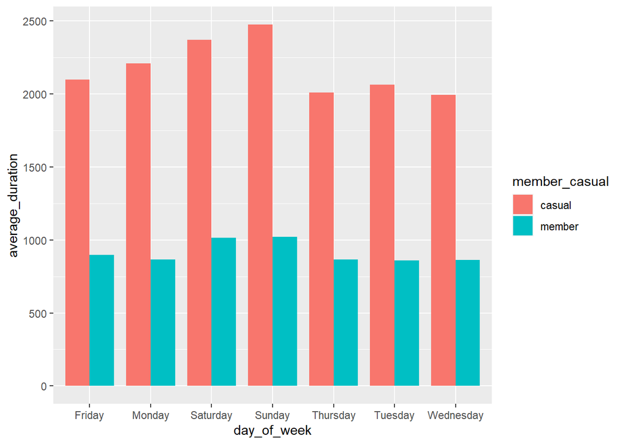

```r
trips %>%
  group_by(member_casual, day_of_week) %>%
  summarise(number_of_rides = n(), average_duration = mean(ride_length_in_sec)) %>%
  arrange(member_casual, day_of_week) %>%
  ggplot(aes(x = day_of_week, y = average_duration, fill = member_casual)) +
  geom_col(position = "dodge", width = 0.8)
```

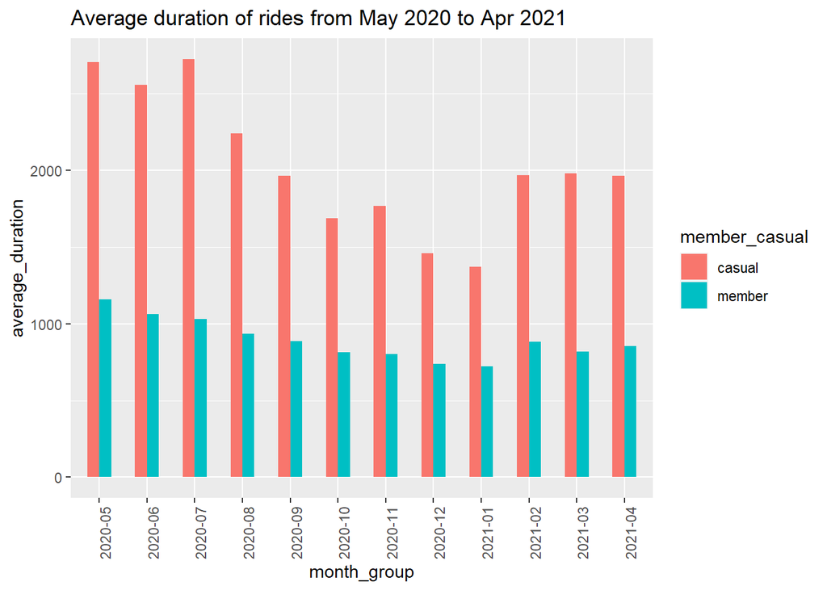

```r
trips %>%
  group_by(month_group, member_casual) %>%
  summarise(number_of_rides = n(), average_duration = mean(ride_length_in_sec)) %>%
  arrange(month_group, member_casual) %>%
  ggplot(aes(x = month_group, y = average_duration, fill = member_casual)) +
  geom_col(position = "dodge", width = 0.5) +
  theme(axis.text.x = element_text(angle = 90)) +
  ggtitle("Average duration of rides from May 2020 to Apr 2021")
```

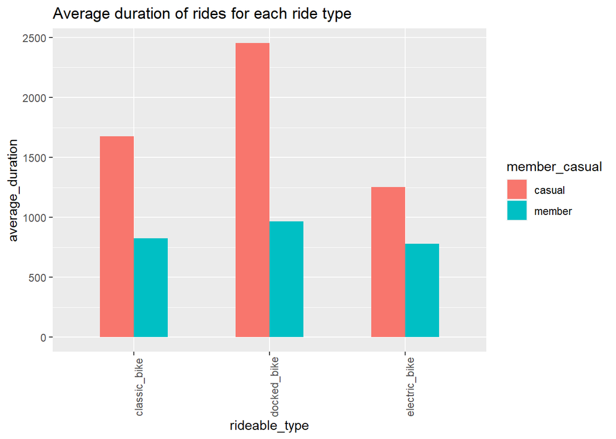

```r
trips %>%
  group_by(rideable_type, member_casual) %>%
  summarise(number_of_rides = n(), average_duration = mean(ride_length_in_sec)) %>%
  arrange(rideable_type, member_casual) %>%
  ggplot(aes(x = rideable_type, y = average_duration, fill = member_casual)) +
  geom_col(position = "dodge", width = 0.5) +
  theme(axis.text.x = element_text(angle = 90)) +
  ggtitle("Average duration of rides for each ride type")
```

##### Export data for further Analysis

```r
agg_data = aggregate(trips$ride_length_in_sec ~ trips$member_casual + trips$day_of_week, FUN = mean)
# write.csv(agg_data, file = 'D:\\Main Folder\\Google Data Analytics Course\\CaseStudy\\Cyclistic_Case_Study\\DataSet\\agg_data.csv')
# write.csv(trips, file = 'D:\\Main Folder\\Google Data Analytics Course\\Case Study\\Cyclistic_Case_Study\\DataSet\\trips.csv')
```